# Exercise 9

Group J: Reed Scott & Lindsey Pekurney

22 March 2022

```r
path.root <- "D:/OneDrive - University of Vermont/Classes/Spring2022/sdhmR/sdhmR-V2022.1" #Reed Laptop Path
#path.root <- "C:/Users/14842/Documents/SDHM/sdhmR-V2022.1" #Lindsey Path
path.ex <- paste(path.root, "/data/exercise/traindat", sep = "") #Path to mod 2
path.preds <- paste(path.root, '/data/exercise/preds', sep = '')
path.figs <- paste(path.root, "/powerpoints/figures", sep = "") #path to save figs
path.gis <- paste(path.root, "/data/gis_layers", sep = "") #path to gis files

# some libraries
library(raster) # FXNS: extent, raster, res, rasterize, values, writeRaster,
#       cellFromXY, extract
library(sf)     # FXNS: st_as_sf, st_as_sfc, st_bbox, st_convex_hull, st_union
#       st_buffer, st_read, st_write, st_intersection, st_geometry,
#       st_drop_geometry, st_coordinates, st_sf
library(terra)  # FXNS: as.data.frame, rast, vect
library(sp)
library(dplyr)
library(tidyverse)
library(data.table)
library(modeest)
library(DAAG)
library(PresenceAbsence)
options("rgdal_show_exportToProj4_warnings"="none") # run this before library(rgdal)
library(rgdal)
library(dismo)
library(maptools)

# source course CRSs
setwd(path.root)
getwd()
```

```
## [1] "D:/OneDrive - University of Vermont/Classes/Spring2022/sdhmR/sdhmR-V2022.1"
```

```r
source("r_code/prjs4_sdhmR.r")
ls(pattern = "prj.") # should be 5 prj.* objects
```

```
## [1] "prj.aeaN83"    "prj.gmerc"     "prj.latlong"   "prj.utmWGSz12"
## [5] "prj.wgs84"
```

## This exercise links to Module 5.3

Submit the completed exercise to us at:

- t.edwards@usu.edu
- eric_tsakiris@fws.gov

## Context

The data are of the *Pinus edulis* Common piñon, the species you dealt with in Exercise #3 – #5. This exercise relies on the dataframe you generated in exercise #6. Hopefully you saved those combined presence:absence dataframe, with the reduced variables you begin SDHM model construction with, or regrettably you will need to return to exercise #6 and re–build that dataframe.

The goal is to: * Produce and interpret variable importance plots * Build a table of accuracy metrics, and AUC plot * Plot map products of the: * (i) probability; and * (ii) classified distribution model * (Save these two maps as **`.img`** files for use later in the course)

Remember, you will have been assigned data for *edulis* having one the following four discrete labels:

- **Seedlings**: these data indicate spatial locations where seedlings of the tree have been found
- **Mortality**: these data indicate spatial locations where mortality has been observed
- **Persistence**: these data have no observed mortality or seedling at given spatial locations
- **Range**: the total dataset, including all spatial locations of seedlings, mortality, and persistence

## The Data

- The dataframe completed in exercise #6.

## Question #1

- Import and explore data
  - **NOTE**: intent is not to reduce number of variables; that was completed in exercise #5. Rather, calculate simple descriptive statistics (mean, sd, n) and boxplots

```r
setwd(path.ex)
load('tr_PERS.RData')
class(tr_PERS)
```

```
## [1] "data.frame"
```

```r
head(tr_PERS)
```

```
##   FNETID PERS106 wgs_xF wgs_yF exp5nrm exp3nrm rough_1k prad_sw_di etpt_5
## 1    194       0     NA     NA      NA      NA       NA         NA     NA
## 2   1922       0     NA     NA      NA      NA       NA         NA     NA
## 3   3813       0     NA     NA      NA      NA       NA         NA     NA
## 4   5186       0     NA     NA      NA      NA       NA         NA     NA
## 5   5594       0     NA     NA      NA      NA       NA         NA     NA
## 6   6226       0     NA     NA      NA      NA       NA         NA     NA
##   mind_yr_av prec_winte tave_sprin UNIQUEID.x cell.wgs_x cell.wgs_y UNIQUEID.y
## 1         NA         NA         NA       <NA>  -112.9988   42.14331       <NA>
## 2         NA         NA         NA       <NA>  -110.6498   42.13498       <NA>
## 3         NA         NA         NA       <NA>  -106.9429   42.12665       <NA>
## 4         NA         NA         NA       <NA>  -107.5510   42.11832       <NA>
## 5         NA         NA         NA       <NA>  -104.1524   42.11832       <NA>
## 6         NA         NA         NA       <NA>  -110.9330   42.10999       <NA>
##    tr.wgs_x tr.wgs_y etpt_5.img etpt_6.img etpt_sprin.img mind_yr_av.img
## 1 -112.9988 42.14331         NA         NA             NA             NA
## 2 -110.6498 42.13498         81         95       27.00000       -866.750
## 3 -106.9429 42.12665         90         99       51.66667      -1162.417
## 4 -107.5510 42.11832         88         98       49.00000      -1144.833
## 5 -104.1524 42.11832         92        101       68.33334      -1299.583
## 6 -110.9330 42.10999         87         97       47.33333      -1092.000
##   prec_winte.img tave_s_hal.img tave_sprin.img tmax_s_hal.img tmax_summe.img
## 1             NA             NA             NA             NA             NA
## 2       26.33333        93.0000      -1.333333       185.0000       225.0000
## 3       17.00000       135.5000      38.333332       213.1667       256.3333
## 4       13.66667       127.3333      31.333334       209.6667       253.0000
## 5        8.00000       163.5000      75.000000       257.6667       299.0000
## 6       21.00000       115.3333      24.000000       211.3333       251.3333
```

```r
drops <- c('wgs_xF','wgs_yF','cell.wgs_x','cell.wgs_y','exp5nrm','exp3nrm','rough_1k','prad_sw_di',
           'etpt_5','mind_yr_av','prec_winte','tave_sprin','UNIQUEID.x'
           ,'UNIQUEID.y')
tr_PERS <- tr_PERS[ ,!(names(tr_PERS) %in% drops)]
tr_PERS <- na.omit(tr_PERS)
dim(tr_PERS)
```

```
## [1] 1942   13
```

```r
#explore etpt5
mean(tr_PERS$etpt_5.img, na.rm = T) #mean returned NA
```

```
## [1] 92.35839
```

```r
sum(is.na(tr_PERS$etpt_5.img)) #checked for number of NAs
```

```
## [1] 0
```

```r
sd(tr_PERS$etpt_5.img, na.rm = T) #standard deviation
```

```
## [1] 5.560058
```

```r
nrow(tr_PERS) - sum(is.na(tr_PERS$etpt_5.img)) #check total N
```

```
## [1] 1942
```

```r
#explore etpt6
mean(tr_PERS$etpt_6.img, na.rm = T) #mean returned NA
```

```
## [1] 100.0278
```

```r
sum(is.na(tr_PERS$etpt_6.img)) #checked for number of NAs
```

```
## [1] 0
```

```r
sd(tr_PERS$etpt_6.img, na.rm = T) #standard deviation
```

```
## [1] 2.18426
```

```r
nrow(tr_PERS) - sum(is.na(tr_PERS$etpt_6.img)) #check total N
```

```
## [1] 1942
```

```r
#explore etpt_sprin
mean(tr_PERS$etpt_sprin.img, na.rm = T) #mean returned NA
```

```
## [1] 69.36011
```

```r
sum(is.na(tr_PERS$etpt_sprin.img)) #checked for number of NAs
```

```
## [1] 0
```

```r
sd(tr_PERS$etpt_sprin.img, na.rm = T) #standard deviation
```

```
## [1] 14.20613
```

```r
nrow(tr_PERS) - sum(is.na(tr_PERS$etpt_sprin.img)) #check total N
```

```
## [1] 1942
```

```r
#explore mind_yr_ave
mean(tr_PERS$mind_yr_av.img, na.rm = T) #mean returned NA
```

```
## [1] -1441.124
```

```r
sum(is.na(tr_PERS$mind_yr_av.img)) #checked for number of NAs
```

```
## [1] 0
```

```r
sd(tr_PERS$mind_yr_av.img, na.rm = T) #standard deviation
```

```
## [1] 334.7886
```

```r
nrow(tr_PERS) - sum(is.na(tr_PERS$mind_yr_av.img)) #check total N
```

```
## [1] 1942
```

```r
#explore prec_winte
mean(tr_PERS$prec_winte.img, na.rm = T) #mean returned NA
```

```
## [1] 23.29059
```

```r
sum(is.na(tr_PERS$prec_winte.img)) #checked for number of NAs
```

```
## [1] 0
```

```r
sd(tr_PERS$prec_winte.img, na.rm = T) #standard deviation
```

```
## [1] 12.59748
```

```r
nrow(tr_PERS) - sum(is.na(tr_PERS$prec_winte.img)) #check total N
```

```
## [1] 1942
```

```r
#explore tave_s_hal
mean(tr_PERS$tave_s_hal.img, na.rm = T) #mean returned NA
```

```
## [1] 169.3242
```

```r
sum(is.na(tr_PERS$tave_s_hal.img)) #checked for number of NAs
```

```
## [1] 0
```

```r
sd(tr_PERS$tave_s_hal.img, na.rm = T) #standard deviation
```

```
## [1] 42.62714
```

```r
nrow(tr_PERS) - sum(is.na(tr_PERS$tave_s_hal.img)) #check total N
```

```
## [1] 1942
```

```r
#explore tave_sprin
mean(tr_PERS$tave_sprin.img, na.rm = T) #mean returned NA
```

```
## [1] 86.88345
```

```r
sum(is.na(tr_PERS$tave_sprin.img)) #checked for number of NAs
```

```
## [1] 0
```

```r
sd(tr_PERS$tave_sprin.img, na.rm = T) #standard deviation
```

```
## [1] 47.30311
```

```r
nrow(tr_PERS) - sum(is.na(tr_PERS$tave_sprin.img)) #check total N
```

```
## [1] 1942
```

```r
#explore tmax_summe
mean(tr_PERS$tmax_summe.img, na.rm = T) #mean returned NA
```

```
## [1] 290.372
```

```r
sum(is.na(tr_PERS$tmax_summe.img)) #checked for number of NAs
```

```
## [1] 0
```

```r
sd(tr_PERS$tmax_summe.img, na.rm = T) #standard deviation
```

```
## [1] 40.88223
```

```r
nrow(tr_PERS) - sum(is.na(tr_PERS$tmax_summe.img)) #check total N
```

```
## [1] 1942
```

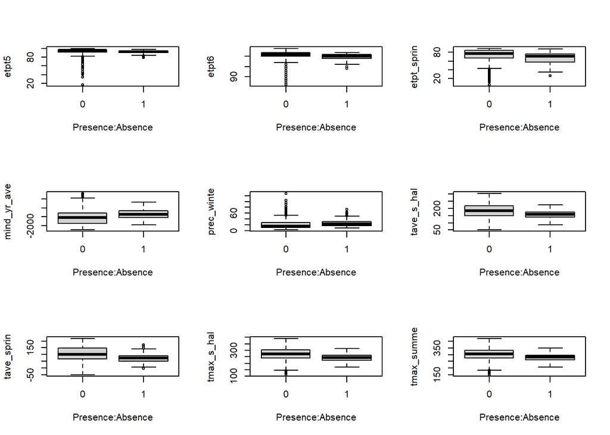

```r
#Boxplots
par(mfrow = c(3, 3))
boxplot(tr_PERS$etpt_5.img ~ tr_PERS$PERS106, xlab = "Presence:Absence",
        ylab = "etpt5", na.rm = T)
boxplot(tr_PERS$etpt_6.img ~ tr_PERS$PERS106, xlab = "Presence:Absence",
        ylab = "etpt6", na.rm = T)
boxplot(tr_PERS$etpt_sprin.img ~ tr_PERS$PERS106, xlab = "Presence:Absence",
        ylab = "etpt_sprin", na.rm = T)
boxplot(tr_PERS$mind_yr_av.img ~ tr_PERS$PERS106, xlab = "Presence:Absence",
        ylab = "mind_yr_ave", na.rm = T)
boxplot(tr_PERS$prec_winte.img ~ tr_PERS$PERS106, xlab = "Presence:Absence",
        ylab = "prec_winte", na.rm = T)
boxplot(tr_PERS$tave_s_hal.img ~ tr_PERS$PERS106, xlab = "Presence:Absence",
        ylab = "tave_s_hal", na.rm = T)
boxplot(tr_PERS$tave_sprin.img ~ tr_PERS$PERS106, xlab = "Presence:Absence",
        ylab = "tave_sprin", na.rm = T)
boxplot(tr_PERS$tmax_s_hal.img ~ tr_PERS$PERS106, xlab = "Presence:Absence",
        ylab = "tmax_s_hal", na.rm = T)
boxplot(tr_PERS$tmax_summe.img ~ tr_PERS$PERS106, xlab = "Presence:Absence",
        ylab = "tmax_summe", na.rm = T)
```

At a glance, every variable beslies etpt5 looks like it could correlate with presence/absence, although none look like they have a particularly strong relationship.

## Question #2

- Construct a MAXENT model using the presence:absence data
- Build plots of variable importance values

```r
head(tr_PERS,2)
```

```
##   FNETID PERS106  tr.wgs_x tr.wgs_y etpt_5.img etpt_6.img etpt_sprin.img
## 2   1922       0 -110.6498 42.13498         81         95       27.00000
## 3   3813       0 -106.9429 42.12665         90         99       51.66667
##   mind_yr_av.img prec_winte.img tave_s_hal.img tave_sprin.img tmax_s_hal.img
## 2       -866.750       26.33333           93.0      -1.333333       185.0000
## 3      -1162.417       17.00000          135.5      38.333332       213.1667
##   tmax_summe.img
## 2       225.0000
## 3       256.3333
```

```r
PERS.xy <- tr_PERS[,3:4]
#Building raster stack + domain
setwd(path.preds)
pers.list <- list.files(pattern = ".img$") # list of .img files; $ strips extra
pers.list # examine
```

```
##  [1] "etpt_5.img"     "etpt_6.img"     "etpt_sprin.img" "exp1nrm.img"
##  [5] "exp3nrm.img"    "exp5nrm.img"    "mind_yr_av.img" "prad_sw_di.img"
##  [9] "prec_w_hal.img" "prec_winte.img" "rough_1k.img"   "tave_s_hal.img"
## [13] "tave_sprin.img" "tmax_s_hal.img" "tmax_summe.img" "topos.img"
```

```r
pers.dom <- stack(pers.list) # build raster stack
pers.dom # examine stack
```

```
## class      : RasterStack
## dimensions : 1518, 1478, 2243604, 16  (nrow, ncol, ncell, nlayers)
## resolution : 0.008333333, 0.008333333  (x, y)
## extent     : -114.6167, -102.3, 29.49167, 42.14167  (xmin, xmax, ymin, ymax)
## crs        : +proj=longlat +datum=WGS84 +no_defs
## names      :       etpt_5,       etpt_6,   etpt_sprin,      exp1nrm,      exp3nrm,      exp5nrm,   mind_yr_av,   prad_sw_di,   prec_w_hal,   prec_winte,     rough_1k,   tave_s_hal,   tave_sprin,   tmax_s_hal,   tmax_summe, ...
## min values :     0.000000,    69.000000,     0.000000, -1152.000000,  -812.000000,  -715.000000, -2294.333252,  6411.166016,     3.666667,     3.333333,     0.000000,    16.166666,   -86.000000,    63.833332,   100.000000, ...
## max values :    100.00000,    104.00000,     90.33334,   1246.00000,    945.00000,    895.00000,    249.33333,  14441.50000,    136.83333,    140.33333,    243.85391,    308.33334,    226.66667,    392.33334,    424.00000, ...
```

```r
names(pers.dom) # examine stack names
```

```
##  [1] "etpt_5"     "etpt_6"     "etpt_sprin" "exp1nrm"    "exp3nrm"
##  [6] "exp5nrm"    "mind_yr_av" "prad_sw_di" "prec_w_hal" "prec_winte"
## [11] "rough_1k"   "tave_s_hal" "tave_sprin" "tmax_s_hal" "tmax_summe"
## [16] "topos"
```

```r
# save 20% presence for testing, 80% training; 5-fold x-val
set.seed(1234) # set.seed if desire repeatability
#library(dismo) # dismo needed for kfold and maxent
fold <- kfold(PERS.xy, k = 5) # data k-folds == 5
pers.tst <- PERS.xy[fold == 1, ] # build test data; the 20%
pers.tr <- PERS.xy[fold != 1, ] # build training data; the 80%

# run maxent model; requires dismo
n.col <- ncol(tr_PERS)
mod1.MAX <- maxent(x = tr_PERS[5:n.col],p = tr_PERS[2]) # call for true pers/abs
```

```
## This is MaxEnt version 3.4.3
```

```r
mod1.MAX
```

```
## class    : MaxEnt
## variables: etpt_5.img etpt_6.img etpt_sprin.img mind_yr_av.img prec_winte.img tave_s_hal.img tave_sprin.img tmax_s_hal.img tmax_summe.img
```

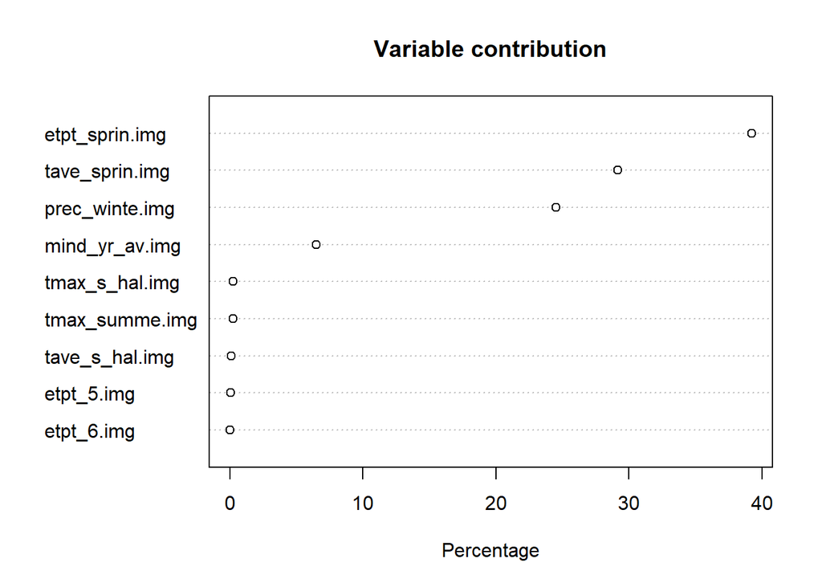

```r
plot(mod1.MAX)
```

## Question #3

- Calculate accuracy metrics (as in Module 3.2 and 3.3, Analytical Intermission) using:
  - Resubstitution approaches, and
  - A 10-fold cross–validation approach

```r
pers <- 'PERS106'
#Resubstitution
mod1.MAX.pred <- predict(mod1.MAX, tr_PERS)
head(mod1.MAX.pred)
```

```
## [1] 0.26126623 0.66315043 0.58507192 0.05296126 0.56311274 0.06810588
```

```r
modl <- 'mod1.MAX'
dat2 <- cbind(modl,tr_PERS[2],mod1.MAX.pred)
head(dat2)
```

```
##       modl PERS106 mod1.MAX.pred
## 2 mod1.MAX       0    0.26126623
## 3 mod1.MAX       0    0.66315043
## 4 mod1.MAX       0    0.58507192
## 5 mod1.MAX       0    0.05296126
## 6 mod1.MAX       0    0.56311274
## 7 mod1.MAX       0    0.06810588
```

```r
names(pers.dom)
```

```
##  [1] "etpt_5"     "etpt_6"     "etpt_sprin" "exp1nrm"    "exp3nrm"
##  [6] "exp5nrm"    "mind_yr_av" "prad_sw_di" "prec_w_hal" "prec_winte"
## [11] "rough_1k"   "tave_s_hal" "tave_sprin" "tmax_s_hal" "tmax_summe"
## [16] "topos"
```

```r
names(pers.dom) <- paste(names(pers.dom),'img')
mod1.val <- evaluate(model = mod1.MAX, p = tr_PERS[tr_PERS$PERS106 == 1, c(3:4)],
                     a = tr_PERS[tr_PERS$PERS106 == 0, c(3:4)],
                     x = pers.dom)
mod1.val
```

```
## class          : ModelEvaluation
## n presences    : 986
## n absences     : 956
## AUC            : 0.8551998
## cor            : 0.6461388
## max TPR+TNR at : 0.4894119
```

```r
threshold(mod1.val)
```

```
##                kappa spec_sens no_omission prevalence equal_sens_spec
## thresholds 0.4894119 0.4894119  0.01385326  0.5076949       0.6338563
##            sensitivity
## thresholds   0.5547931
```

```r
mod.cut <- threshold(mod1.val)
mod.cut
```

```
##                kappa spec_sens no_omission prevalence equal_sens_spec
## thresholds 0.4894119 0.4894119  0.01385326  0.5076949       0.6338563
##            sensitivity
## thresholds   0.5547931
```

```r
mod1.acc <- presence.absence.accuracy(dat2, threshold = mod.cut[[2]],st.dev=F)
tss <- mod1.acc$sensitivity + mod1.acc$specificity
```

```r
# Simple 10 fold code
set.seed(1234) # set.seed for repeatability
pers.xf <- sample(rep(c(1:10), length = nrow(tr_PERS))) # vector of random xfolds
mod1.predXF <- rep(0, length = nrow(tr_PERS)) # empty vector of 0
xfold <- 10 # set No. xfolds
# simple loop for xfold
for (i in 1:xfold) {
        tr <- tr_PERS[pers.xf != i, ] # training not eq. i
        te <- tr_PERS[pers.xf == i, ] # test eq. i
        mx <- maxent(tr_PERS[5:ncol(tr_PERS)], tr_PERS[2], data = tr)
        # maxent model on training. first value = predictors, second = pres/abs
        mod1.predXF[pers.xf == i] <- predict(mx, te) # predict to test
}
```

```
## This is MaxEnt version 3.4.3
## This is MaxEnt version 3.4.3
## This is MaxEnt version 3.4.3
## This is MaxEnt version 3.4.3
## This is MaxEnt version 3.4.3
## This is MaxEnt version 3.4.3
## This is MaxEnt version 3.4.3
## This is MaxEnt version 3.4.3
## This is MaxEnt version 3.4.3
## This is MaxEnt version 3.4.3
```

```r
head(mod1.predXF) # examine vector xfold prediction
```

```
## [1] 0.26126623 0.66315043 0.58507192 0.05296126 0.56311274 0.06810588
```

```r
# examine resubstitution and cross-validation estimates
head(mod1.MAX.pred) # examine resub prediction
```

```
## [1] 0.26126623 0.66315043 0.58507192 0.05296126 0.56311274 0.06810588
```

```r
head(mod1.predXF) # examine xval prediction
```

```
## [1] 0.26126623 0.66315043 0.58507192 0.05296126 0.56311274 0.06810588
```

```r
cross.val <- cbind(modl, tr_PERS[2], mod1.predXF) # build dataframe
head(cross.val, 2) # examine; NOTE will differ each run unless seed is saved
```

```
##       modl PERS106 mod1.predXF
## 2 mod1.MAX       0   0.2612662
## 3 mod1.MAX       0   0.6631504
```

```r
#calculate model accuracies#
mod1.accXF <- presence.absence.accuracy(cross.val, threshold = mod.cut[[2]],st.dev=F)
tss <- mod1.accXF$sensitivity + mod1.acc$specificity - 1
mod1.accXF <- cbind(mod1.acc[1:7],tss)
mod1.accXF
```

```
##           model threshold       PCC sensitivity specificity     Kappa       AUC
## 1 mod1.MAX.pred 0.4894119 0.7981462   0.9411765   0.6506276 0.5944148 0.8551998
##         tss
## 1 0.5918041
```

## Question #4

- Build 2 prediction maps:
  - A raw probability estimate for each cell in the modelling domain; and
  - A classified map based on the selected threshold from Question #4

```r
setwd(path.gis)
states <- st_read(dsn = ".", layer = "na_states_wgs") # import shapefile
#create a probability model
pers.prob.MAX <- predict(pers.dom, mod1.MAX,
                     type = "response", fun = predict, index = 2, overwrite = T) # prediction raster
pers.prob.MAX # examine
```

```
## class      : RasterLayer
## dimensions : 1518, 1478, 2243604  (nrow, ncol, ncell)
## resolution : 0.008333333, 0.008333333  (x, y)
## extent     : -114.6167, -102.3, 29.49167, 42.14167  (xmin, xmax, ymin, ymax)
## crs        : +proj=longlat +datum=WGS84 +no_defs
## source     : memory
## names      : layer
## values     : 1.048621e-05, 0.7762663  (min, max)
```

```r
# next reclassify based on threshold mod.cut per above
pers.class.MAX <- reclassify(pers.prob.MAX, c(0,mod.cut[[2]],0,
                                      mod.cut[[2]],1,1),overwrite=TRUE)
pers.class.MAX
```

```
## class      : RasterLayer
## dimensions : 1518, 1478, 2243604  (nrow, ncol, ncell)
## resolution : 0.008333333, 0.008333333  (x, y)
## extent     : -114.6167, -102.3, 29.49167, 42.14167  (xmin, xmax, ymin, ymax)
## crs        : +proj=longlat +datum=WGS84 +no_defs
## source     : memory
## names      : layer
## values     : 0, 1  (min, max)
```

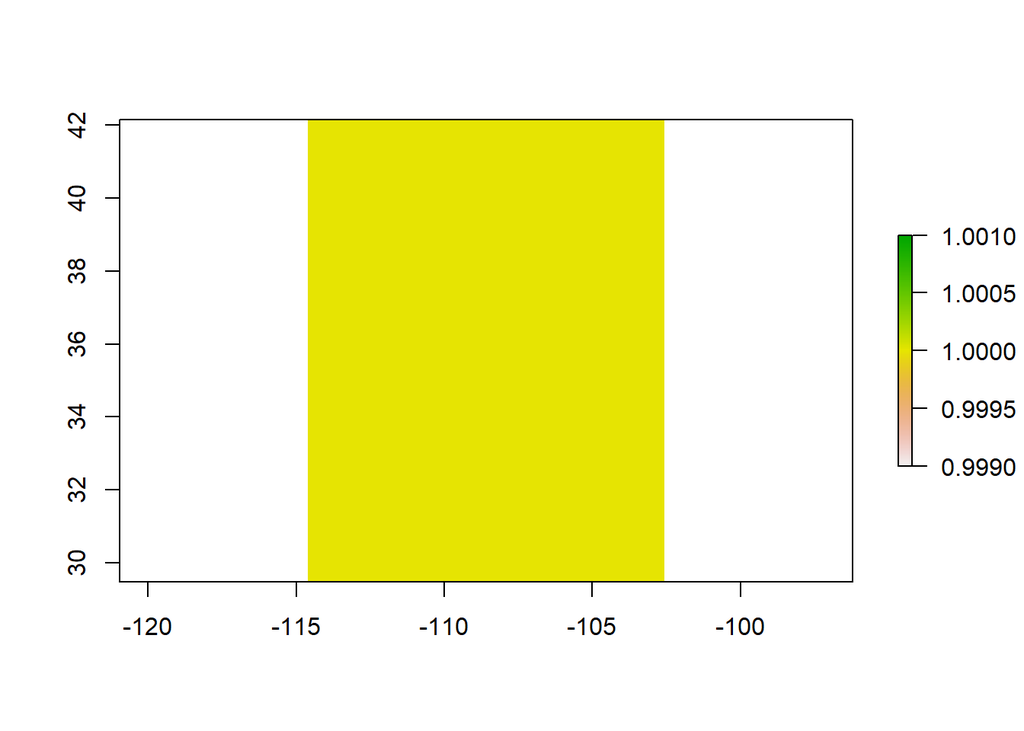

```r
#restrict class and prob models to domain
setwd(path.ex)
load('pers.PPsA.RData')
pres.bufpt <-raster(pers.bufR)
plot(pers.bufR)
```

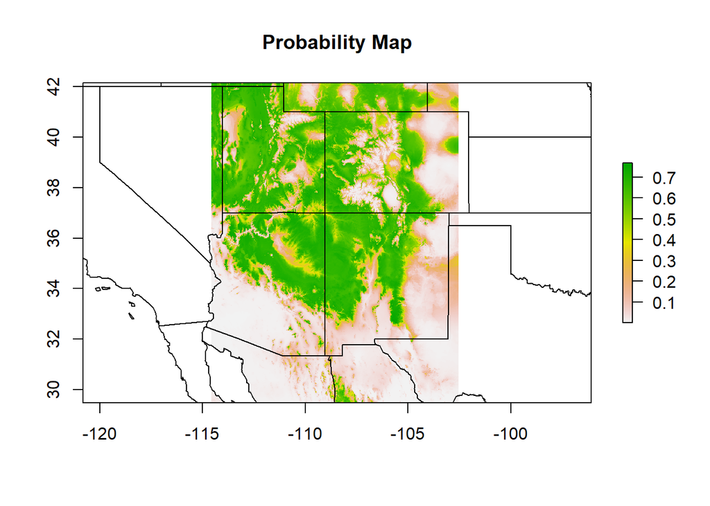

```r
new.pers.bufR <- projectRaster(pers.bufR, pers.class.MAX)
pers.class.MAX <- pers.class.MAX*new.pers.bufR
pers.prob.MAX <- pers.prob.MAX*new.pers.bufR

par(mfrow=c(1,1))
#Plot probability map#
plot(pers.prob.MAX, axes = T, main = 'Probability Map')
plot(st_geometry(states), add = T)
```

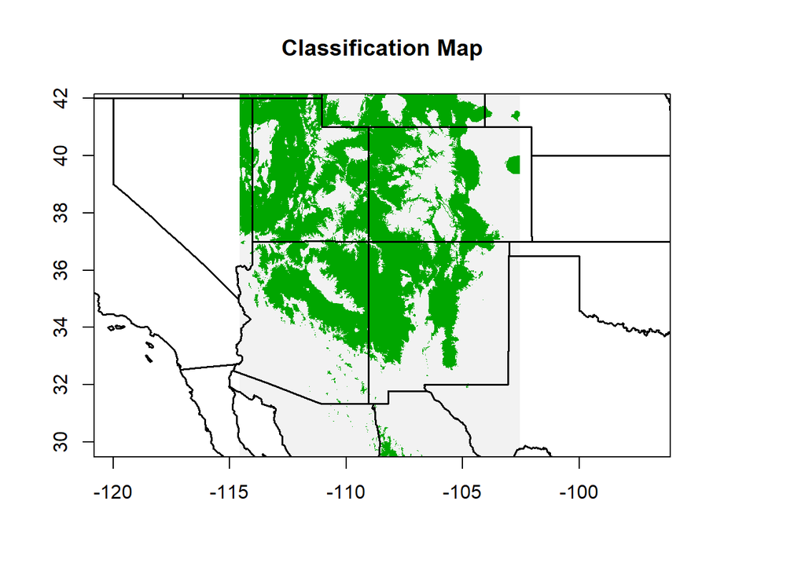

```r
#Classification Map#
plot(pers.class.MAX, legend = F, axes = T, main = "Classification Map") # plot classification map
plot(st_geometry(states), add = T, lwd = 1.5) # add state boundaries
```

## Question #5

- Save your data as R objects:
  - Accuracy metrics as a dataframe;
  - Classification threshold as a stand–alone scalar
  - Both prediction maps as **`.img`** format
- Save these R objects in a **`.RData`** file

These data will be used again in Module 10, Ensemble Models.

```r
setwd(path.ex)
save.image(pers.class.MAX ,pers.prob.MAX,  file= 'ex9.RData')
```

```
## Error in !is.null(version) && version < 2: invalid 'y' type in 'x && y'
```

```r
save(cross.val,dat2,mod.cut,mod1.acc,mod1.accXF,mod1.MAX,mod1.val,mx,pers.class.MAX,pers.prob.MAX,PERS.xy, file = 'ex9.RData')
save.image()
```

## The Challenge Question – See If You Can Do It !!!

This is actually a fun challenge. It will allow you see the impact of decision sets on resultant SDHMs.

- Strip the absence points from the imported dataset
- Allow the MAXENT process to select absences from the background modelling frame
- Build this MAXENT model
- Calculate accuracy metrics
- Build the prediction maps
- Compare this model to the model generated in Questions #2 – #5.